# Etherscan Evaluation

Olivia Modesto

2025-03-05

### Nielsen

#### 1: Visibilità dello stato del sistema

Vogliamo valutare se il sistema tiene gli utenti informati su quello che sta succedendo, con un feedback appropriato e in tempi appropriati. Inoltre, se le informazioni fornite agli utenti incoraggiano gli utenti ad agire.

##### La Homepage : etherscan.io

La pagina principale propone informazioni riguardo la cryptovaluta ETH: gli ultimi sei blocchi, le ultime sei transazioni, il prezzo ETH e il prezzo del gas.  
Il prezzo di ETH e il prezzo del gas sono ripetuti in alto a sinistra: la sezione di cui sono parte rimane fissa anche passando ad altre pagine. In questa sezioni ci sono i menu a tendina, la documentazione e dove fare login.  
Centrale è la barra di ricerca: per qualsiasi cryptovaluta non ETH oppure per qualsiasi wallet si deve utilizzare la barra.  
Complessivamente, la pagina sembra orientata a utenti che svolgono attività sulla catena. Essa fornisce informazioni utili per chi deve svolgere operazioni sulla catena Ethereum. Per gli sviluppatori esiste una voce nel menu a tendina.  
Passando il cursore sopra si ottiene una risposta immediata (da feedback appropriato)

##### La pagina di un wallet: Luna Fondation Guard

Trovato con search bar conoscendo il nome pubblico

Il sistema tiene gli utenti informati ?

Il sistema da appropriate feedback ?

Passando il cursore sopra si ottiene una risposta immediata (da feedback appropriato)

Compel Users to Action ?

Fornisce informazioni utili per sapere se la currency è di interesse.  
Sotto la voce Contract permette di interagire con il contract.

Communication creates trust ?

Il system status è comunicato chiaramente

#### 2: Match Between the System and the Real World

Vogliamo valutare se Etherscan utilizza un linguaggio famigliare agli utenti, se segue convenzioni e se le informazioni sono presentate in un modo coerente.  
La versione del sito valutata è la versione in inglese. Sotto le impostazioni si può cambiare lingua.  
Complessivamente Etherscan utilizza la terminologia corretta. Esso presuppone che gli utenti abbiano conoscenze nel campo della finanza e delle cryptovalute. Esso propone informazioni dettagliate in modo chiaro e ordinato e presuppone che gli utenti sappiano interpretarle.  
Se ci sono delle possibili ambiguità riguardo delle voci, allora vengono indicati degli *i* che forniscono informazioni aggiuntive (vedi la voce *Cards*).

#### 5: Error Prevention

Vogliamo valutare se Etherscan ha delle misure per prevenire errori.

##### La Homepage : etherscan.io

Non ci sono operazioni da svolgere direttamente. Ti porta alle altre pagine senza messaggi di warning.

##### La pagina di una cryptovaluta : USTC

Uniche operazioni sono Read Contract Write Contract.

##### La pagina di un wallet: Luna Fondation Guard

Uniche operazioni sono Read Contract Write Contract.

#### 6: Recognition Rather than Recall

Vogliamo valutare se Etherscan minimizza il carico di memoria sull’utente.  
Etherscan fornisce molto supporto al recall. Come spiegato in precedenza parti delle pagine rimangono sempre visibili e sono forniti suggerimenti nella barra di ricerca.

#### 7: Flexibility and Efficiency of Use

##### La Homepage : etherscan.io

##### La pagina di una cryptovaluta : USTC

##### La pagina di un wallet: Luna Fondation Guard

#### 8: Aesthetic and Minimalist Design

Sì

##### La Homepage : etherscan.io

##### La pagina di una cryptovaluta : USTC

##### La pagina di un wallet: Luna Fondation Guard

#### 9: Help Users Recognize, Diagnose, and Recover from Errors

##### La Homepage : etherscan.io

Se la search non restituisce nulla, ci sono dei suggerimenti.

##### La pagina di una cryptovaluta : USTC

##### La pagina di un wallet: Luna Fondation Guard

#### 10: Help and Documentation

C’è il link al supporto in alto a destra.

##### La Homepage : etherscan.io

##### La pagina di una cryptovaluta : USTC

##### La pagina di un wallet: Luna Fondation Guard

### Tasks Principali

```
Ottenere le informazioni riguardo ai trasferimenti
Ottenere le informazioni riguardo ai prezzi USTC
Ottenere le informazioni riguardo al market cap
Ottenere le informazioni riguardo il white paper
Studiare la pressione di vendita
Ottenere le informazioni riguardo la Luna Foundation Guard
```

### Informazioni disponibli

Un altro parametro importante riguarda le risorse messe a disposizione dalle piattaforme. Per risorse si intende:

- quali informazioni sono disponibili ?  
  i blocchi i gas fee le transazioni le cryptovalute hanno una loro pagina dedicata il market cap di ETH documentazione ulteriori strumenti
- quali catene blockchain sono accessibili ?  
  Ethereum Mainnet  
  Beaconscan ETH2  
  Sepolia Testnet  
  Holesky Testnet
- di ciascuna catena, quali blocchi  
  Ethereum Mainnet dal primo blocco (0x0)  
  Beaconscan ETH2 dal blocco con slot 2  
  Sepolia dal blocco 0x0  
  Holesky dal blocco 0x0
- se i dati sono aggiornati
- i cryptovalue sono descritte in dettaglio
- i wallet sono descritti in dettaglio
- non è possibile rielaborare i dati in qualche modo. È esportare parte dei dati

### I costi

(aggiornato al 5 Marzo 2025)

Etherscan offre cinque piani tariffari, che riguardano l’API:

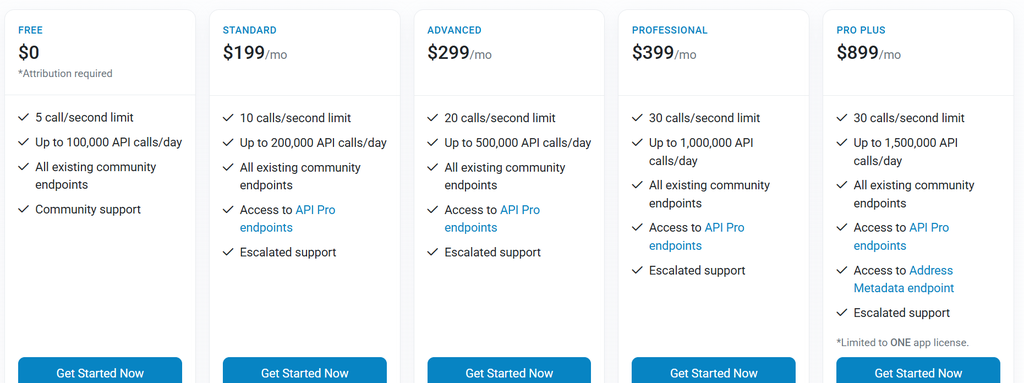

- si analizzano i costi:

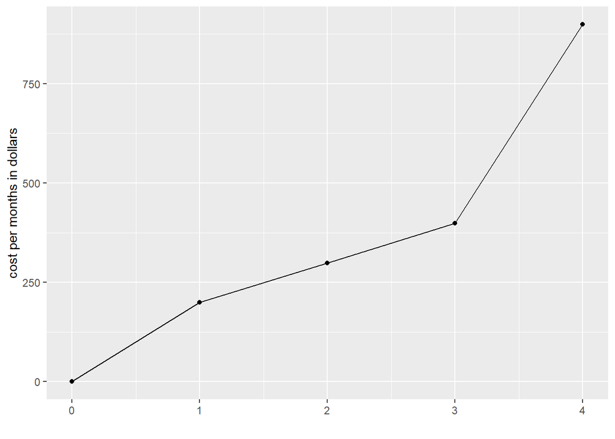

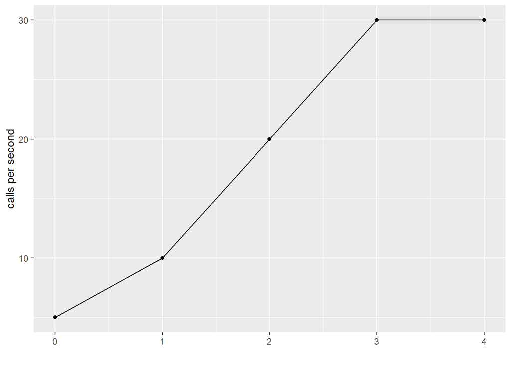

[figure not shown]

## Bibliografia

https://www.nngroup.com/articles/ten-usability-heuristics/